# Risk of Business Failure

Libraries

```r
# install.packages("sjmisc")
# devtools::install_github("ropensci/skimr")

library(skimr)   # advenced summary
library(ggplot2) # ggplot2 graph
library(plyr)
library(hrbrthemes)
library(forcats)
```

Setup & Aida dataset import

```r
# clean all
rm(list=ls())

# working dir
wdir = "C:/Users/falle/OneDrive - University of Pisa/Data Science/Statistical Methods for Data Science/smdproject2021"
setwd(wdir)

# import aida dataset
load(file="aida.RData")

# For each attribute name, replace all white space whit dot symbol
colnames(aida) <- gsub(" ",".",colnames(aida))
```

Summary

```r
skim(aida)
```

Data summary

| Name | aida |
| --- | --- |
| Number of rows | 1894412 |
| Number of columns | 80 |
| _______________________ |  |
| Column type frequency: |  |
| character | 3 |
| factor | 6 |
| numeric | 71 |
| ________________________ |  |
| Group variables | None |

**Variable type: character**

| skim_variable | n_missing | complete_rate | min | max | empty | n_unique | whitespace |
| --- | --- | --- | --- | --- | --- | --- | --- |
| Company.name | 0 | 1 | 2 | 254 | 0 | 1639641 | 0 |
| File | 0 | 1 | 15 | 32 | 0 | 219 | 0 |
| Tax.code.number | 0 | 1 | 11 | 16 | 0 | 1894412 | 0 |

**Variable type: factor**

| skim_variable | n_missing | complete_rate | ordered | n_unique | top_counts |
| --- | --- | --- | --- | --- | --- |
| ATECO.2007code | 18327 | 0.99 | FALSE | 1678 | 412: 174850, 681: 101475, 682: 67526, 561: 53433 |
| Legal.form | 383 | 1.00 | FALSE | 18 | S.R: 1309834, S.R: 215926, S.R: 142003, S.C: 98527 |
| Legal.status | 0 | 1.00 | FALSE | 10 | Act: 1185392, Dis: 226698, In : 166628, Dis: 141635 |
| Province | 0 | 1.00 | FALSE | 105 | Rom: 240940, Mil: 190358, Nap: 95470, Tor: 54311 |
| Registered.office.address.-.Commune.ISTAT.code | 0 | 1.00 | FALSE | 7724 | 058: 197501, 015: 141361, 063: 46220, 001: 35267 |
| Registered.office.address.-.Region | 0 | 1.00 | FALSE | 20 | Lom: 388670, Laz: 289035, Cam: 177935, Ven: 154890 |

**Variable type: numeric**

| skim_variable | n_missing | complete_rate | mean | sd | p0 | p25 | p50 | p75 | p100 | hist |
| --- | --- | --- | --- | --- | --- | --- | --- | --- | --- | --- |
| Banks/turnover%Last.avail..yr | 1034070 | 0.45 | 10.34 | 18.93 | 0.00 | 0.00 | 0.01 | 12.83 | 1.000000e+02 | ▇▁▁▁▁ |
| Banks/turnover%Year.-.1 | 1087625 | 0.43 | 11.18 | 19.46 | 0.00 | 0.00 | 0.08 | 14.89 | 1.000000e+02 | ▇▁▁▁▁ |
| Banks/turnover%Year.-.2 | 1139731 | 0.40 | 11.59 | 19.77 | 0.00 | 0.00 | 0.14 | 15.87 | 1.000000e+02 | ▇▁▁▁▁ |
| Cash.Flowth.EURLast.avail..yr | 3793 | 1.00 | 107.42 | 10332.58 | -2936683.00 | -4.84 | 2.24 | 25.24 | 8.009206e+06 | ▁▇▁▁▁ |
| Cash.Flowth.EURYear.-.1 | 215639 | 0.89 | 121.05 | 7944.72 | -1151190.83 | -3.03 | 4.22 | 29.17 | 4.622253e+06 | ▇▁▁▁▁ |
| Cash.Flowth.EURYear.-.2 | 420268 | 0.78 | 128.69 | 8670.39 | -601364.00 | -2.22 | 5.78 | 32.35 | 5.988016e+06 | ▇▁▁▁▁ |
| Cost.of.debit.(%)%Last.avail..yr | 1425562 | 0.25 | 5.77 | 4.83 | 0.00 | 1.99 | 4.60 | 8.54 | 2.000000e+01 | ▇▅▂▂▁ |
| Cost.of.debit.(%)%Year.-.1 | 1433376 | 0.24 | 5.94 | 4.76 | 0.00 | 2.27 | 4.86 | 8.65 | 2.000000e+01 | ▇▆▃▂▁ |
| Cost.of.debit.(%)%Year.-.2 | 1454700 | 0.23 | 6.20 | 4.72 | 0.00 | 2.61 | 5.22 | 8.89 | 2.000000e+01 | ▇▆▃▂▁ |
| Current.liabilities/Tot.ass.%Last.avail..yr | 37247 | 0.98 | 0.82 | 0.30 | 0.00 | 0.74 | 1.00 | 1.00 | 4.920000e+00 | ▆▇▁▁▁ |
| Current.liabilities/Tot.ass.%Year.-.1 | 237436 | 0.87 | 0.81 | 0.30 | 0.00 | 0.71 | 1.00 | 1.00 | 4.780000e+00 | ▆▇▁▁▁ |
| Current.liabilities/Tot.ass.%Year.-.2 | 436714 | 0.77 | 0.80 | 0.30 | 0.00 | 0.69 | 1.00 | 1.00 | 4.800000e+00 | ▆▇▁▁▁ |
| Current.ratioLast.avail..yr | 187789 | 0.90 | 1.59 | 1.61 | 0.00 | 0.69 | 1.12 | 1.83 | 1.000000e+01 | ▇▂▁▁▁ |
| Current.ratioYear.-.1 | 364180 | 0.81 | 1.62 | 1.58 | 0.00 | 0.77 | 1.14 | 1.83 | 1.000000e+01 | ▇▂▁▁▁ |
| Current.ratioYear.-.2 | 544339 | 0.71 | 1.63 | 1.57 | 0.00 | 0.81 | 1.16 | 1.84 | 1.000000e+01 | ▇▂▁▁▁ |
| Debt/EBITDA.ratio%Last.avail..yr | 774995 | 0.59 | -0.80 | 45.32 | -999.88 | 0.00 | 0.00 | 0.95 | 9.995900e+02 | ▁▁▇▁▁ |
| Debt/EBITDA.ratio%Year.-.1 | 864089 | 0.54 | -0.35 | 46.82 | -999.97 | 0.00 | 0.00 | 1.67 | 9.993600e+02 | ▁▁▇▁▁ |
| Debt/EBITDA.ratio%Year.-.2 | 937800 | 0.50 | 0.15 | 47.31 | -998.67 | 0.00 | 0.00 | 2.13 | 9.997300e+02 | ▁▁▇▁▁ |
| Debt/equity.ratio%Last.avail..yr | 746857 | 0.61 | 1.74 | 25.52 | -992.68 | 0.00 | 0.00 | 0.53 | 9.993600e+02 | ▁▁▇▁▁ |
| Debt/equity.ratio%Year.-.1 | 843372 | 0.55 | 2.29 | 28.27 | -996.08 | 0.00 | 0.00 | 0.90 | 9.998800e+02 | ▁▁▇▁▁ |
| Debt/equity.ratio%Year.-.2 | 922107 | 0.51 | 2.63 | 30.16 | -994.93 | 0.00 | 0.00 | 1.14 | 9.953500e+02 | ▁▁▇▁▁ |
| EBITDA/Vendite%Last.avail..yr | 360190 | 0.81 | -9.87 | 99.50 | -999.90 | -1.96 | 5.51 | 16.85 | 9.980100e+02 | ▁▁▇▁▁ |
| EBITDA/Vendite%Year.-.1 | 487633 | 0.74 | -4.26 | 88.72 | -999.87 | 0.27 | 5.97 | 16.63 | 9.980000e+02 | ▁▁▇▁▁ |
| EBITDA/Vendite%Year.-.2 | 634997 | 0.66 | -1.09 | 83.00 | -999.96 | 1.00 | 6.35 | 16.73 | 9.996200e+02 | ▁▁▇▁▁ |
| EBITDAth.EURLast.avail..yr | 3747 | 1.00 | 121.96 | 8146.26 | -2001922.00 | -3.59 | 4.65 | 38.07 | 5.919802e+06 | ▁▇▁▁▁ |
| EBITDAth.EURYear.-.1 | 215613 | 0.89 | 144.99 | 9930.13 | -7751332.00 | -2.03 | 8.27 | 45.58 | 6.035040e+06 | ▁▁▇▁▁ |
| EBITDAth.EURYear.-.2 | 420227 | 0.78 | 163.45 | 8102.08 | -531037.00 | -1.22 | 11.42 | 52.80 | 6.451267e+06 | ▇▁▁▁▁ |
| Incorporation.year | 691 | 1.00 | 2003.53 | 12.34 | 1900.00 | 1999.00 | 2006.00 | 2012.00 | 2.019000e+03 | ▁▁▁▂▇ |
| Interest/Turnover.(%)%Last.avail..yr | 332001 | 0.82 | 3.19 | 9.50 | 0.00 | 0.04 | 0.42 | 2.00 | 1.000000e+02 | ▇▁▁▁▁ |
| Interest/Turnover.(%)%Year.-.1 | 471552 | 0.75 | 3.21 | 9.33 | 0.00 | 0.06 | 0.48 | 2.13 | 1.000000e+02 | ▇▁▁▁▁ |
| Interest/Turnover.(%)%Year.-.2 | 626932 | 0.67 | 3.38 | 9.39 | 0.00 | 0.08 | 0.59 | 2.39 | 1.000000e+02 | ▇▁▁▁▁ |
| Last.accounting.closing.date | 0 | 1.00 | 2014.97 | 4.05 | 1990.00 | 2012.00 | 2017.00 | 2018.00 | 2.019000e+03 | ▁▁▁▃▇ |
| LeverageLast.avail..yr | 4554 | 1.00 | 13.49 | 161.66 | -1995.59 | 1.05 | 2.50 | 7.60 | 9.988340e+03 | ▇▁▁▁▁ |
| LeverageYear.-.1 | 216014 | 0.89 | 15.10 | 163.41 | -1999.08 | 1.25 | 3.11 | 9.20 | 9.991840e+03 | ▇▁▁▁▁ |
| LeverageYear.-.2 | 420657 | 0.78 | 16.12 | 165.49 | -1998.31 | 1.40 | 3.49 | 10.11 | 9.979300e+03 | ▇▁▁▁▁ |
| Liquidity.ratioLast.avail..yr | 163303 | 0.91 | 1.34 | 1.56 | 0.00 | 0.40 | 0.92 | 1.55 | 1.000000e+01 | ▇▁▁▁▁ |
| Liquidity.ratioYear.-.1 | 339778 | 0.82 | 1.33 | 1.52 | 0.00 | 0.43 | 0.93 | 1.53 | 1.000000e+01 | ▇▁▁▁▁ |
| Liquidity.ratioYear.-.2 | 521019 | 0.72 | 1.32 | 1.50 | 0.00 | 0.44 | 0.93 | 1.51 | 1.000000e+01 | ▇▁▁▁▁ |
| Net.financial.positionth.EURLast.avail..yr | 745606 | 0.61 | 493.58 | 53578.75 | -6108645.00 | -19.17 | -0.89 | 68.64 | 5.444152e+07 | ▇▁▁▁▁ |
| Net.financial.positionth.EURYear.-.1 | 842273 | 0.56 | 539.99 | 54756.37 | -2985400.00 | -20.30 | -0.75 | 96.27 | 5.418047e+07 | ▇▁▁▁▁ |
| Net.financial.positionth.EURYear.-.2 | 920975 | 0.51 | 612.81 | 55920.43 | -1798205.00 | -21.22 | -0.58 | 119.77 | 5.268033e+07 | ▇▁▁▁▁ |
| Net.working.capitalth.EURLast.avail..yr | 2859 | 1.00 | 216.91 | 40308.16 | -41486331.00 | -20.13 | 10.93 | 105.33 | 1.359079e+07 | ▁▁▁▇▁ |
| Net.working.capitalth.EURYear.-.1 | 214879 | 0.89 | 253.98 | 38596.99 | -35486901.00 | -16.73 | 15.31 | 126.34 | 1.140541e+07 | ▁▁▁▇▁ |
| Net.working.capitalth.EURYear.-.2 | 419560 | 0.78 | 314.54 | 34987.68 | -31469999.00 | -15.04 | 19.24 | 145.94 | 1.580661e+07 | ▁▁▁▇▁ |
| Number.of.employeesLast.avail..yr | 116013 | 0.94 | 7.88 | 176.07 | 0.00 | 0.00 | 0.00 | 4.00 | 1.277020e+05 | ▇▁▁▁▁ |
| Number.of.employeesYear.-.1 | 325969 | 0.83 | 8.39 | 158.90 | 0.00 | 0.00 | 1.00 | 5.00 | 1.369280e+05 | ▇▁▁▁▁ |
| Number.of.employeesYear.-.2 | 520120 | 0.73 | 8.93 | 166.02 | 0.00 | 0.00 | 1.00 | 5.00 | 1.355140e+05 | ▇▁▁▁▁ |
| Profit.(loss)th.EURLast.avail..yr | 6273 | 1.00 | -27.37 | 78053.14 | -106390190.00 | -8.84 | 0.00 | 10.92 | 8.009205e+06 | ▁▁▁▁▇ |
| Profit.(loss)th.EURYear.-.1 | 216735 | 0.89 | 44.93 | 9696.37 | -2877000.00 | -6.82 | 0.46 | 11.96 | 6.235645e+06 | ▁▇▁▁▁ |
| Profit.(loss)th.EURYear.-.2 | 420623 | 0.78 | 25.42 | 12039.09 | -11460133.00 | -6.12 | 0.80 | 12.58 | 4.521093e+06 | ▁▁▁▇▁ |
| Return.on.asset.(ROA)%Last.avail..yr | 14068 | 0.99 | -10.64 | 70.71 | -999.99 | -6.15 | 0.68 | 6.11 | 9.961900e+02 | ▁▁▇▁▁ |
| Return.on.asset.(ROA)%Year.-.1 | 217738 | 0.89 | -4.64 | 50.88 | -999.97 | -3.32 | 1.31 | 6.33 | 9.974400e+02 | ▁▁▇▁▁ |
| Return.on.asset.(ROA)%Year.-.2 | 420354 | 0.78 | -2.18 | 42.52 | -999.47 | -2.11 | 1.72 | 6.53 | 9.955100e+02 | ▁▁▇▁▁ |
| Return.on.equity.(ROE)%Last.avail..yr | 452155 | 0.76 | 5.66 | 38.67 | -150.00 | -5.27 | 3.48 | 21.80 | 1.499900e+02 | ▁▁▇▂▁ |
| Return.on.equity.(ROE)%Year.-.1 | 534423 | 0.72 | 5.57 | 37.22 | -150.00 | -4.55 | 3.67 | 20.89 | 1.500000e+02 | ▁▁▇▂▁ |
| Return.on.equity.(ROE)%Year.-.2 | 659434 | 0.65 | 5.26 | 35.98 | -150.00 | -4.14 | 3.59 | 19.68 | 1.500000e+02 | ▁▁▇▂▁ |
| Return.on.investment.(ROI).(%)%Last.avail..yr | 1150584 | 0.39 | 3.21 | 11.66 | -30.00 | -1.96 | 2.27 | 10.08 | 3.000000e+01 | ▁▂▇▅▂ |
| Return.on.investment.(ROI).(%)%Year.-.1 | 1171960 | 0.38 | 3.65 | 11.45 | -30.00 | -1.50 | 2.79 | 10.42 | 3.000000e+01 | ▁▂▇▅▂ |
| Return.on.investment.(ROI).(%)%Year.-.2 | 1209449 | 0.36 | 3.95 | 11.25 | -30.00 | -1.19 | 3.09 | 10.59 | 3.000000e+01 | ▁▂▇▅▂ |
| Return.on.sales.(ROS)%Last.avail..yr | 692210 | 0.63 | 1.50 | 13.82 | -50.00 | -1.03 | 2.91 | 8.32 | 3.000000e+01 | ▁▁▂▇▂ |
| Return.on.sales.(ROS)%Year.-.1 | 750415 | 0.60 | 2.05 | 12.97 | -50.00 | -0.18 | 3.06 | 8.15 | 3.000000e+01 | ▁▁▂▇▂ |
| Return.on.sales.(ROS)%Year.-.2 | 851385 | 0.55 | 2.47 | 12.44 | -50.00 | 0.09 | 3.25 | 8.16 | 3.000000e+01 | ▁▁▂▇▂ |
| Solvency.ratio.(%)%Last.avail..yr | 195987 | 0.90 | 30.08 | 33.46 | -50.00 | 5.58 | 21.43 | 52.64 | 1.000000e+02 | ▁▇▇▅▃ |
| Solvency.ratio.(%)%Year.-.1 | 330068 | 0.83 | 28.72 | 31.70 | -50.00 | 5.60 | 19.73 | 48.53 | 1.000000e+02 | ▁▇▇▃▃ |
| Solvency.ratio.(%)%Year.-.2 | 494947 | 0.74 | 28.19 | 30.69 | -50.00 | 5.73 | 19.09 | 46.58 | 1.000000e+02 | ▁▇▇▃▃ |
| Total.assets.turnover.(times)Last.avail..yr | 56101 | 0.97 | 0.84 | 0.97 | 0.00 | 0.01 | 0.54 | 1.31 | 5.000000e+00 | ▇▃▁▁▁ |
| Total.assets.turnover.(times)Year.-.1 | 249794 | 0.87 | 0.86 | 0.95 | 0.00 | 0.04 | 0.61 | 1.33 | 5.000000e+00 | ▇▃▁▁▁ |
| Total.assets.turnover.(times)Year.-.2 | 445924 | 0.76 | 0.87 | 0.94 | 0.00 | 0.05 | 0.65 | 1.35 | 5.000000e+00 | ▇▃▁▁▁ |
| Total.assetsth.EURLast.avail..yr | 82 | 1.00 | 6557.54 | 1165741.71 | 0.00 | 58.39 | 234.20 | 878.29 | 1.304071e+09 | ▇▁▁▁▁ |
| Total.assetsth.EURYear.-.1 | 212414 | 0.89 | 6216.48 | 692114.24 | 0.00 | 80.46 | 289.59 | 1021.13 | 5.093774e+08 | ▇▁▁▁▁ |
| Total.assetsth.EURYear.-.2 | 417258 | 0.78 | 6703.16 | 708684.72 | 0.00 | 99.60 | 341.33 | 1157.40 | 4.476925e+08 | ▇▁▁▁▁ |

Aggiungo la variabile ‘failed’ al dataframe, la quale indica se un’azienda è fallita (Yes = no active) o no (No = active). Abbiamo deciso che un’azienda si definisce ‘failed’ se e solo se non è attiva, indipendentemente dalla causa. Lo stato di una azienda attiva è specificato nel testo del problema oppure visibile dai seguenti istogrammi.

```r
# Non esistono valori nulli
aida[is.na(aida$Legal.status),]
```

| ATECO.2007code | Banks/turnover%Last.avail..yr | Banks/turnover%Year.-.1 | Banks/turnover%Year.-.2 | Cash.Flowth.EURLast.avail..yr | Cash.Flowth.EURYear.-.1 | Cash.Flowth.EURYear.-.2 | Company.name | Cost.of.debit.(%)%Last.avail..yr | Cost.of.debit.(%)%Year.-.1 | Cost.of.debit.(%)%Year.-.2 | Current.liabilities/Tot.ass.%Last.avail..yr | Current.liabilities/Tot.ass.%Year.-.1 | Current.liabilities/Tot.ass.%Year.-.2 | Current.ratioLast.avail..yr | Current.ratioYear.-.1 | Current.ratioYear.-.2 | Debt/EBITDA.ratio%Last.avail..yr | Debt/EBITDA.ratio%Year.-.1 | Debt/EBITDA.ratio%Year.-.2 | Debt/equity.ratio%Last.avail..yr | Debt/equity.ratio%Year.-.1 | Debt/equity.ratio%Year.-.2 | EBITDA/Vendite%Last.avail..yr | EBITDA/Vendite%Year.-.1 | EBITDA/Vendite%Year.-.2 | EBITDAth.EURLast.avail..yr | EBITDAth.EURYear.-.1 | EBITDAth.EURYear.-.2 | File | … |
| --- | --- | --- | --- | --- | --- | --- | --- | --- | --- | --- | --- | --- | --- | --- | --- | --- | --- | --- | --- | --- | --- | --- | --- | --- | --- | --- | --- | --- | --- | --- |

```r
# Tabella dei contenuti
table(aida$Legal.status)
```

```
                      Active Active (default of payments)
                     1185392                         3839
       Active (receivership)                   Bankruptcy
                         484                       106690
                   Dissolved       Dissolved (bankruptcy)
                      226698                         6768
        Dissolved (demerger)      Dissolved (liquidation)
                         877                       141635
          Dissolved (merger)               In liquidation
                       55401                       166628
```

```r
# make the operator
'%!in%' <- function(x,y)!('%in%'(x,y))

# add new empty column
aida$failed <- NULL

# for each 'Legal status' which contains 'Active' substring fill in new column 'No' else 'Yes'
act_vector <- c('Active','Active (default of payments)','Active (receivership)')
aida[aida$Legal.status %in% act_vector,'Failed'] <- 'No'
aida[aida$Legal.status %!in% act_vector,'Failed'] <- 'Yes'
```

Legal Status Histogram

```r
table(aida$Legal.status)*100/nrow(aida)
```

```
                      Active Active (default of payments)
                 62.57308336                   0.20264863
       Active (receivership)                   Bankruptcy
                  0.02554882                   5.63182666
                   Dissolved       Dissolved (bankruptcy)
                 11.96666829                   0.35726125
        Dissolved (demerger)      Dissolved (liquidation)
                  0.04629405                   7.47646235
          Dissolved (merger)               In liquidation
                  2.92444305                   8.79576354
```

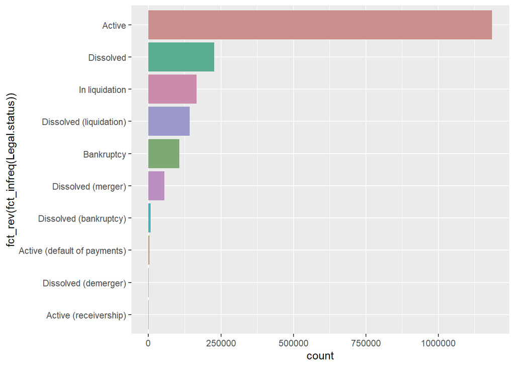

```r
ggplot(data=aida, aes(x=fct_rev(fct_infreq(Legal.status)), fill=Legal.status)) +
  geom_bar() +
  scale_fill_hue(c = 40) +
  theme(legend.position="none") +
  coord_flip()
```

Failed/Not Failed Company Histogram

```r
table(aida$Failed)*100/nrow(aida)
```

```
      No      Yes
62.80128 37.19872
```

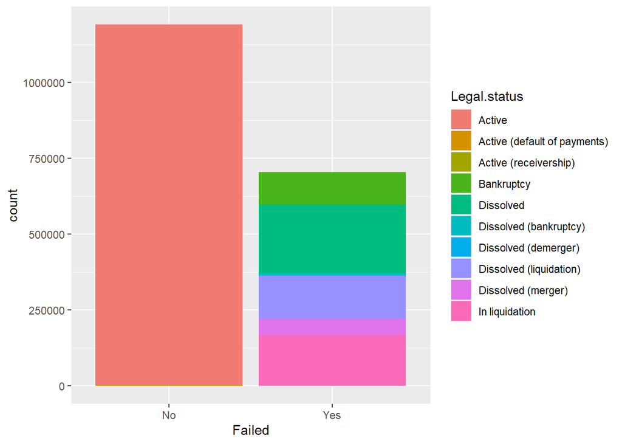

```r
ggplot(data=aida, aes(x=Failed, fill=Legal.status)) +
  geom_bar() +
  scale_fill_hue(c = 90)
```

Add a column with the respective ISTAT sector of the company. In particular first two digits of ATECO 2007code identify the company sector.

```r
#Delete record with ADECO code null (18327)
aida <- aida[!is.na(aida$ATECO.2007code),]

# Add the attribute 'ATECO.Sector.Code' which contain the characters of the sector identified
# by the first two ATECO 2007 code digits.
aida$ATECO.Sector.Code <- NULL
aida$ATECO.Sector.Code <- substr(aida$ATECO.2007code, 0, 2)

# Make a dataframe called istat.sectors.map, which contains two features:
# - ATECO.Sector.Code: first two digits of 'ATECO 2007code'
# - ATECO.Sector.Name: the respective sector name of that ATECO.Sector.Code
#  Istat sectors can be found in https://www.istat.it/it/archivio/17888

ATECO.Sector.Code <- c('01', '02', '03', '05', '06', '07', '08', '09', '10', '11', '12', '13', '14', '15', '16', '17', '18', '19', '20', '21', '22', '23', '24', '25', '26', '27', '28', '29', '30', '31', '32', '33', '35', '36', '37', '38', '39', '41', '42', '43', '45', '46', '47', '49', '50', '51', '52', '53', '55', '56', '58', '59', '60', '61', '62', '63', '64', '65', '66', '68', '69', '70', '71', '72', '73', '74', '75', '77', '78', '79', '80', '81', '82', '84', '85', '86', '87', '88', '90', '91', '92', '93', '94', '95', '96', '97', '98', '99', '00')

ATECO.Sector.Name <- c('A', 'A', 'A', 'B', 'B', 'B', 'B', 'B', 'C', 'C', 'C', 'C', 'C', 'C', 'C', 'C', 'C', 'C', 'C', 'C', 'C', 'C', 'C', 'C', 'C', 'C', 'C', 'C', 'C', 'C', 'C', 'C', 'D', 'E', 'E', 'E', 'E', 'F', 'F', 'F', 'G', 'G', 'G', 'H', 'H', 'H', 'H', 'H', 'I', 'I', 'J', 'J', 'J', 'J', 'J', 'J', 'K', 'K', 'K', 'L', 'M', 'M', 'M', 'M', 'M', 'M', 'M', 'N', 'N', 'N', 'N', 'N', 'N', 'O', 'P', 'Q', 'Q', 'Q', 'R', 'R', 'R', 'R', 'S', 'S', 'S', 'T', 'T','U', 'no_sec')

istat.sectors.map <- data.frame(ATECO.Sector.Code=ATECO.Sector.Code, ATECO.Sector.Name=ATECO.Sector.Name)

# Merge istat.sectors.map with aida dataframe, by ATECO.Sector.Code key
aida <- merge(aida,istat.sectors.map,by="ATECO.Sector.Code")

# Delete ATECO.Sector.Code feature, because we already have the secor name.
aida$ATECO.Sector.Code <- NULL

# Cast ATECO.Sector.Name as Factor
aida$ATECO.Sector.Name <- as.factor(aida$ATECO.Sector.Name)

# Description of ISTAT sectors
# https://www.istat.it/it/archivio/17888
# http://www.fr.camcom.gov.it/sites/default/files/cciaa/RinnovoConsiglio/ateco-2007-struttura.pdf
```

#save(aida, file="/Users/francescogemignani/Google Drive/SMD/_Risk-of-business-failure/aida_check.RData“) #aida <- load(”/Users/francescogemignani/Google Drive/SMD/_Risk-of-business-failure/aida_check.RData")

## AGE

Define company age as the difference between Incorporation.year and Last.accounting.closing.date. First of all we deal these variables: missing values and anomalies.

```r
# Handle Incorporation.year
# - missing values present
# - no evident anomalies
age.df <- aida
summary(age.df$'Incorporation.year')
```

```
   Min. 1st Qu.  Median    Mean 3rd Qu.    Max.    NA's
   1900    1999    2006    2004    2012    2019     661
```

```r
# Print the median for each sector of Incorporation.year
tapply(age.df$Incorporation.year,age.df$ATECO.Sector.Name,median, na.rm=TRUE)
```

```
     A      B      C      D      E      F      G      H      I      J      K
2006.0 1995.0 2003.0 2010.0 2004.0 2006.0 2007.0 2007.0 2010.0 2007.0 2008.0
     L      M      N no_sec      O      P      Q      R      S      T      U
2004.0 2008.0 2008.0 2005.0 2004.5 2008.0 2007.0 2009.0 2009.0 2012.0 2001.0
```

```r
# For each ATECO.Sector.Name group replace the 'Incorporation year' nan value with the respective median.
# In this way the result is more accurate than computing the median on entire Incorporation.year values.
compute.median <- function(x) replace(x, is.na(x), median(x, na.rm = TRUE))
age.df <- ddply(age.df,~ATECO.Sector.Name,transform, Incorporation.year = compute.median(`Incorporation.year`))


# Handle Last.accounting.closing.date:
# no missing values and evident anomalies
summary(age.df$Last.accounting.closing.date)
```

```
   Min. 1st Qu.  Median    Mean 3rd Qu.    Max.
   1990    2012    2017    2015    2018    2019
```

Compute ‘Age’ attribute.

```r
# Make 'Age' attribute
age.df$Age <- age.df$Last.accounting.closing.date - age.df$Incorporation.year
age.df$Age <- as.integer(age.df$Age)

# There are some company with negative age, with Incorporation year greater then Last accounting closing date. We suppose that are digit error. Therefore we remove all that records
summary(age.df$Age)
```

```
   Min. 1st Qu.  Median    Mean 3rd Qu.    Max.
 -12.00    3.00    7.00   11.52   16.00  118.00
```

```r
head(age.df[age.df$Age < 0,c('Age','Last.accounting.closing.date','Incorporation.year')])
```

|  | Age | Last.accounting.closing.date | Incorporation.year |
| --- | --- | --- | --- |
| 18542 | -2 | 2002 | 2004 |
| 49522 | -1 | 1997 | 1998 |
| 52243 | -2 | 1997 | 1999 |
| 56838 | -3 | 1995 | 1998 |
| 61639 | -1 | 1993 | 1994 |
| 63211 | -1 | 2005 | 2006 |

```r
# Remove negative ages
age.df <- age.df[age.df$Age >= 0,]
```

Age Histogram

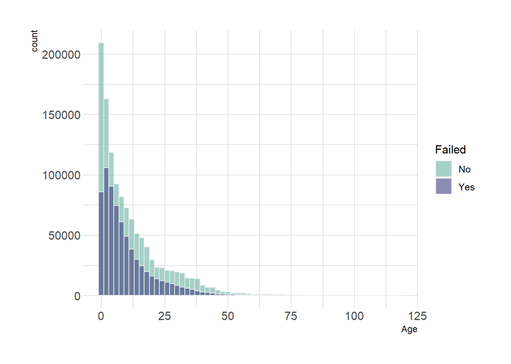

```r
ggplot(data = age.df) +
  geom_histogram(mapping=aes(x=Age, fill=Failed),binwidth = 2,color="#e9ecef", alpha=0.6, position = 'identity') +
    scale_fill_manual(values=c("#69b3a2", "#404080"))+
    theme_ipsum() +
    labs(fill='Failed')
```

ROI

```r
# Reduce the aida dataset from all that companies which report ROI of all last three years. Obviously all
# missing values are been deleted. The dataset is composed by 386.629 companies (20.61%)
roi.df <- aida
colnames(roi.df)[65:67] <- c('ROI.last.avail','ROI.one.year.ago','ROI.two.years.ago')

b<- nrow(roi.df)
roi.df <- roi.df[!is.na(roi.df$ROI.last.avail),]
roi.df <- roi.df[!is.na(roi.df$ROI.one.year.ago),]
roi.df <- roi.df[!is.na(roi.df$ROI.two.years.ago),]
a <- nrow(roi.df)
ratio <- a*100/b

# Add attribute avg.roi which rappresents the average ROI of the last three years.
roi.df$avg.roi <- (roi.df$ROI.last.avail + roi.df$ROI.one.year.ago + roi.df$ROI.two.years.ago)/3

summary(roi.df$avg.roi)
```

```
    Min.  1st Qu.   Median     Mean  3rd Qu.     Max.
-29.6033  -0.6067   3.0467   3.8917   8.7467  29.6900
```

Average Return On Investments Histogram

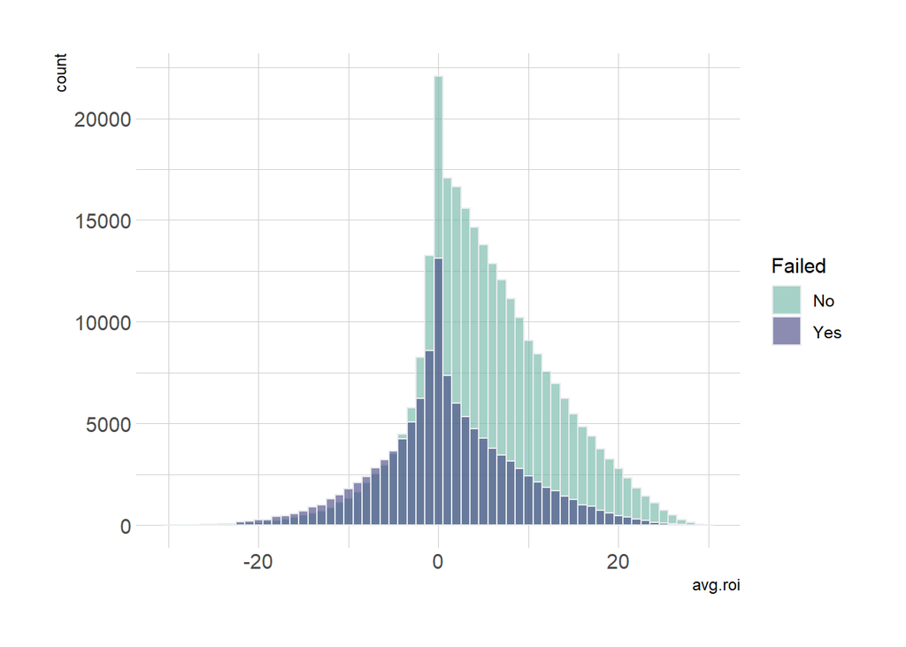

```r
ggplot(data = roi.df) +
  geom_histogram(mapping=aes(x=avg.roi, fill=Failed),binwidth = 1,color="#e9ecef", alpha=0.6, position = 'identity') +
    scale_fill_manual(values=c("#69b3a2", "#404080"))+
    theme_ipsum() +
    labs(fill='Failed')
```

Size

```r
# Deleting missing values
size.df <- aida

b<- nrow(size.df)
size.df <- size.df[!is.na(size.df$Number.of.employeesLast.avail..yr),]
size.df <- size.df[!is.na(size.df$`Number.of.employeesYear.-.1`),]
size.df <- size.df[!is.na(size.df$`Number.of.employeesYear.-.2`),]
a <- nrow(size.df)
ratio <- a*100/b

# Add attribute avg.size which rappresents the average size of the last three years.
size.df$avg.size <- round((size.df$Number.of.employeesLast.avail..yr
                              + size.df$`Number.of.employeesYear.-.1` + size.df$`Number.of.employeesYear.-.2`)/3)

summary(size.df$avg.size)
```

```
     Min.   1st Qu.    Median      Mean   3rd Qu.      Max.
     0.00      0.00      1.00      9.28      5.00 133381.00
```

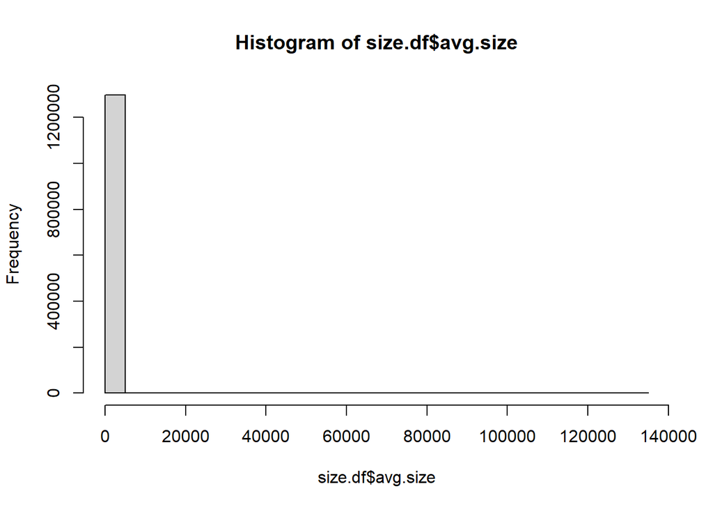

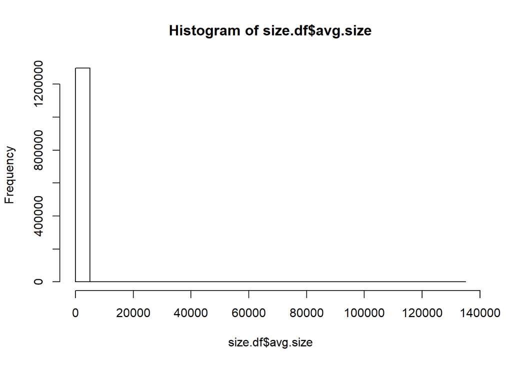

```r
#Long tail distribution, we can try a log transformation
plot(hist(size.df$avg.size))
```

```r
#Adding the log of the size
size.df$log.avg.size = log(size.df$avg.size) #Rounding?
```

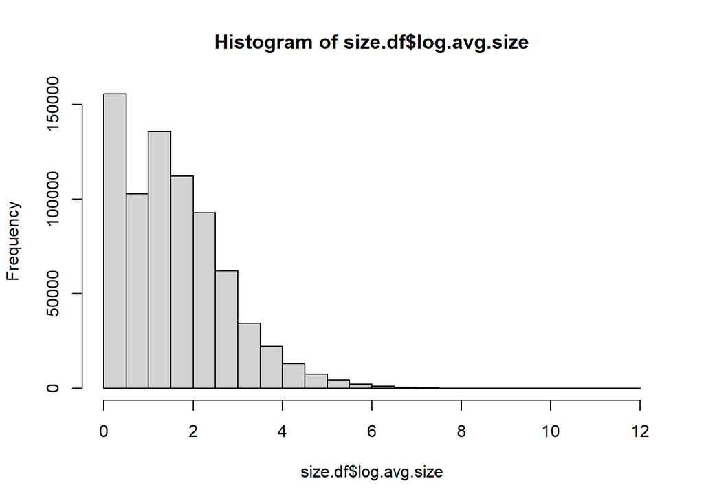

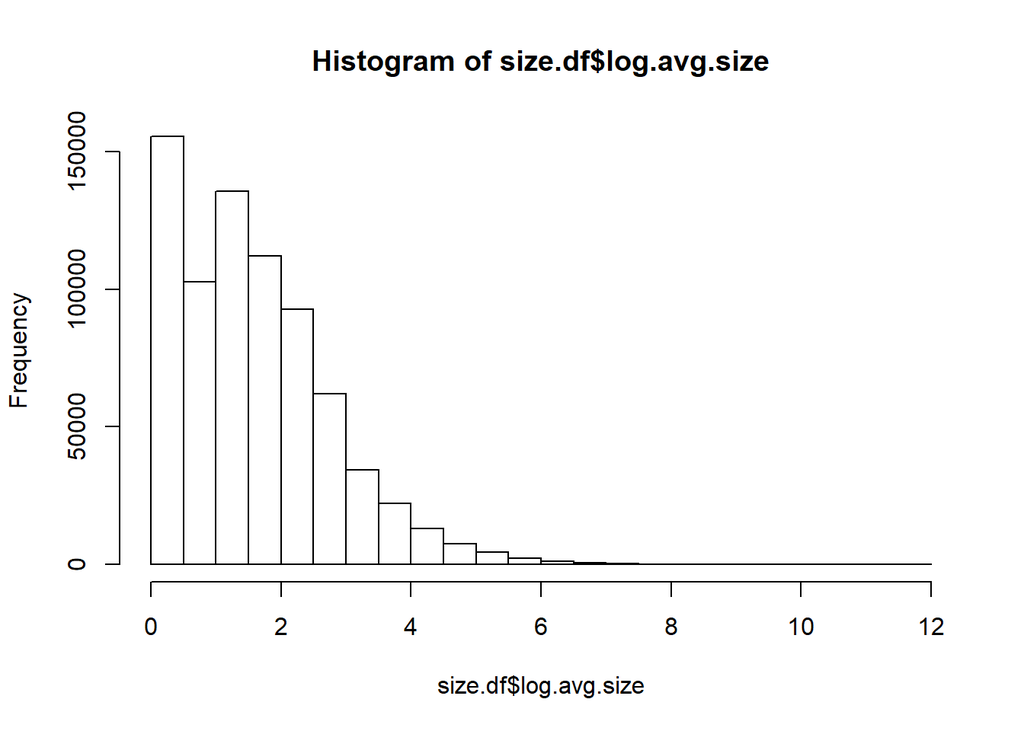

```r
plot(hist(size.df$log.avg.size))
```

Plot histogram of size distribution by Failed

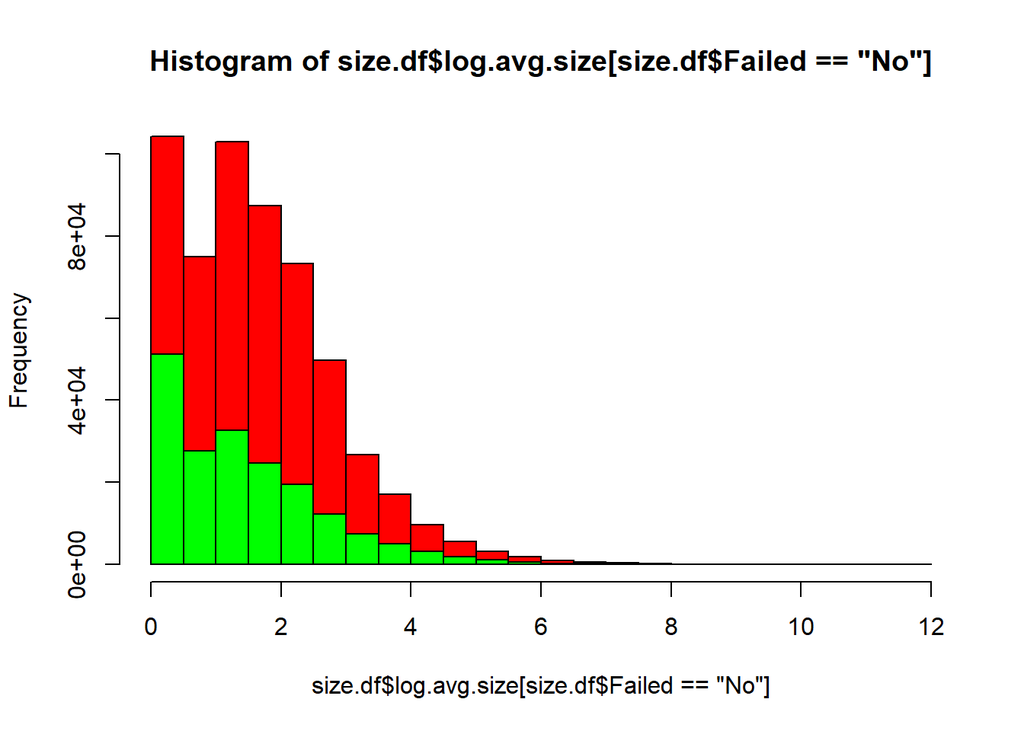

```r
h1 = hist(size.df$log.avg.size[size.df$Failed=='No'], plot = FALSE, freq=FALSE)
h2 = hist(size.df$log.avg.size[size.df$Failed=='Yes'], plot = FALSE, freq=FALSE)
plot(h1, col = "red")
plot(h2, col = 'green',add=T)
```

Plot density of size distribution by Failed

[figure not shown]

```r
d1 = density(size.df$log.avg.size[size.df$Failed=='No'], plot = FALSE)
d2 = density(size.df$log.avg.size[size.df$Failed=='Yes'], plot = FALSE)
plot(d1, col = "red", main="Distribution of size by Legal status")
lines(d2, col = 'green')
legend("topright", c("Failed","Active"), lty=c(1,1), col = c("red","green"))
```

Size alternative

```r
# Number.of.employeesLast.avail..yr
# Missing values are present (114101), we can replace it with the value of Number.of.employeesYear.-.1 or Number.of.employeesYear.-.2 if present
# otherwise with the median/mean Size of the corresponding Ateco sectors
summary(aida$Number.of.employeesLast.avail..yr)
```

```
     Min.   1st Qu.    Median      Mean   3rd Qu.      Max.      NA's
     0.00      0.00      1.00      7.94      4.00 127702.00    114101
```

```r
aida$Number.of.employeesLast.avail..yr = ifelse(is.na(aida$Number.of.employeesLast.avail..yr),
                                                aida$`Number.of.employeesYear.-.1`,
                                                aida$Number.of.employeesLast.avail..yr)
#63096 remaining NA
summary(aida$Number.of.employeesLast.avail..yr)
```

```
     Min.   1st Qu.    Median      Mean   3rd Qu.      Max.      NA's
     0.00      0.00      1.00      7.85      4.00 127702.00     63096
```

```r
aida$Number.of.employeesLast.avail..yr = ifelse(is.na(aida$Number.of.employeesLast.avail..yr),
                                                aida$`Number.of.employeesYear.-.2`,
                                                aida$Number.of.employeesLast.avail..yr)

aida <- aida[!is.na(aida$Number.of.employeesLast.avail..yr),]
#50946 remaining NA
summary(aida$Number.of.employeesLast.avail..yr)
```

```
     Min.   1st Qu.    Median      Mean   3rd Qu.      Max.
     0.00      0.00      1.00      7.86      4.00 127702.00
```

Solvency ratio

```r
summary(aida$`Solvency.ratio.(%)%Last.avail..yr`)
```

```
   Min. 1st Qu.  Median    Mean 3rd Qu.    Max.    NA's
 -50.00    5.78   21.75   30.28   52.81  100.00  186968
```

```r
# Deleting missing values
solvency.df <- aida

b<- nrow(solvency.df)
solvency.df <- solvency.df[!is.na(solvency.df$`Solvency.ratio.(%)%Last.avail..yr`),]
solvency.df <- solvency.df[!is.na(solvency.df$`Solvency.ratio.(%)%Year.-.1`),]
solvency.df <- solvency.df[!is.na(solvency.df$`Solvency.ratio.(%)%Year.-.2`),]
a <- nrow(size.df)
ratio <- a*100/b

# Add attribute avg.size which rappresents the average size of the last three years.
solvency.df$avg.solvency <- round((solvency.df$`Solvency.ratio.(%)%Last.avail..yr`
                              + solvency.df$`Solvency.ratio.(%)%Year.-.1` + solvency.df$`Solvency.ratio.(%)%Year.-.2`)/3)

summary(solvency.df$avg.solvency)
```

```
   Min. 1st Qu.  Median    Mean 3rd Qu.    Max.
 -50.00    7.00   22.00   30.12   49.00  100.00
```

Distribution of solvency ratio

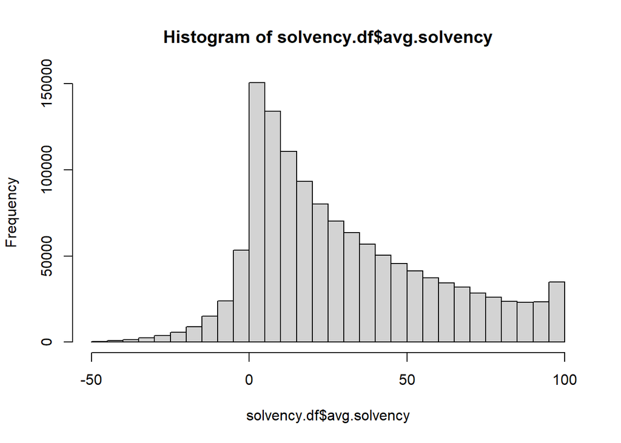

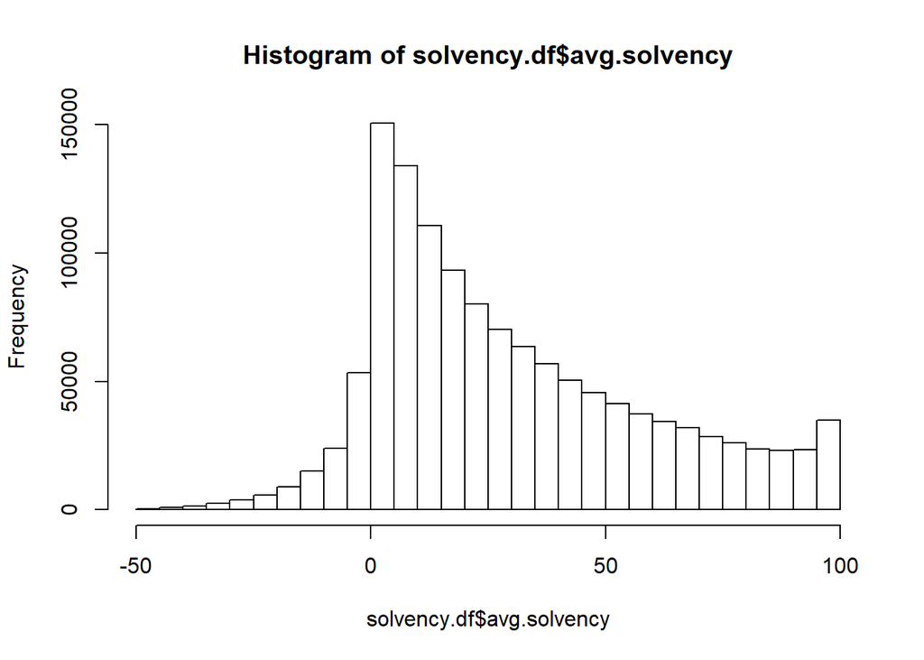

```r
plot(hist(solvency.df$avg.solvency))
```

Distribution of solvency ratio by Legal Status

[figure not shown]

```r
d1 = density(solvency.df$avg.solvency[solvency.df$Failed=='No'], plot = FALSE)
d2 = density(solvency.df$avg.solvency[solvency.df$Failed=='Yes'], plot = FALSE)
plot(d1, col = "red", main="Distribution of solvency ratio by Legal status")
lines(d2, col = 'green')
legend("topright", c("Failed","Active"), lty=c(1,1), col = c("red","green"))
```

istat.sectors <- list(‘01’ = ‘A’, ‘02’ = ‘A’, ‘03’ = ‘A’, ‘05’ = ‘B’, ‘06’ = ‘B’, ‘07’ = ‘B’, ‘08’ = ‘B’, ‘09’ = ‘B’, ‘10’ = ‘C’, ‘11’ = ‘C’, ‘12’ = ‘C’, ‘13’ = ‘C’, ‘14’ = ‘C’, ‘15’ = ‘C’, ‘16’ = ‘C’, ‘17’ = ‘C’, ‘18’ = ‘C’, ‘19’ = ‘C’, ‘20’ = ‘C’, ‘21’ = ‘C’, ‘22’ = ‘C’, ‘23’ = ‘C’, ‘24’ = ‘C’, ‘25’ = ‘C’, ‘26’ = ‘C’, ‘27’ = ‘C’, ‘28’ = ‘C’, ‘29’ = ‘C’, ‘30’ = ‘C’, ‘31’ = ‘C’, ‘32’ = ‘C’, ‘33’ = ‘C’, ‘35’ = ‘D’, ‘36’ = ‘E’, ‘37’ = ‘E’, ‘38’ = ‘E’, ‘39’ = ‘E’, ‘41’ = ‘F’, ‘42’ = ‘F’, ‘43’ = ‘F’, ‘45’ = ‘G’, ‘46’ = ‘G’, ‘47’ = ‘G’, ‘49’ = ‘H’, ‘50’ = ‘H’, ‘51’ = ‘H’, ‘52’ = ‘H’, ‘53’ = ‘H’, ‘55’ = ‘I’, ‘56’ = ‘I’, ‘58’ = ‘J’, ‘59’ = ‘J’, ‘60’ = ‘J’, ‘61’ = ‘J’, ‘62’ = ‘J’, ‘63’ = ‘J’, ‘64’ = ‘K’, ‘65’ = ‘K’, ‘66’ = ‘K’, ‘68’ = ‘L’, ‘69’ = ‘M’, ‘70’ = ‘M’, ‘71’ = ‘M’, ‘72’ = ‘M’, ‘73’ = ‘M’, ‘74’ = ‘M’, ‘75’ = ‘M’, ‘77’ = ‘N’, ‘78’ = ‘N’, ‘79’ = ‘N’, ‘80’ = ‘N’, ‘81’ = ‘N’, ‘82’ = ‘N’, ‘84’ = ‘O’, ‘85’ = ‘P’, ‘86’ = ‘Q’, ‘87’ = ‘Q’, ‘88’ = ‘Q’, ‘90’ = ‘R’, ‘91’ = ‘R’, ‘92’ = ‘R’, ‘93’ = ‘R’, ‘94’ = ‘S’, ‘95’ = ‘S’, ‘96’ = ‘S’, ‘97’ = ‘T’, ‘98’ = ‘T’, ‘99’ = ‘U’, ‘00’ = ‘no_sec’)

TODO 1. Codici ATECO classificazione per sezioni. DOC (elimino mv) 2. definizione di age 2. definizione di size 3. feature reduction - attributi con oltre il 50% di valori mancanti - elimino record quando - sostituisco quando

1.059291e+03

apici accentati in ggplot2 creare nuova colonna Bankrupted…come vedo se una substring è contenuta in un altra e creo una nuova colonna descrizione degli attributi ha senso definire age come differenza tra incorporporation year e last accounting rate? incorporation year ha 691 mv. Elimino o sostituisco con median?

## TO DO & NOTES

mean(aida$‘Incorporation year’, na.rm=TRUE)

0. numero di aziende attive e
1. definizione di age
2. definizione di size
3. feature reduction
- attributi con oltre il 50% di valori mancanti
- elimino record quando
- sostituisco quando